# Batch Model Operations

Mazama Science

3/19/2020

```r
knitr::opts_chunk$set(message = FALSE, warning = FALSE)
library(AirFireModeling)
setModelDataDir('~/MS/Data/BlueSky/')
```

## Batch Mode

Following the 0.25 “batch” update, the `AirFireModeling` package now supports batch multi-threaded operations for model rasters. This means a user can download models, create plots and visualizations, and preform complex calculations quickly and efficiently.

#### Memory

Execution has only a small memory footprint because of the underlying `raster` package integration, which is used to process the model in chunks, i.e., they read, compute, and write blocks of data, without loading all values into memory at once.

#### Examples

Batch operations download and operate on a `list()` of `Raster*` (typically `RasterBrick`) objects, which can be loaded via `raster_load()` when we provide either multiple dates, models, or paths to models.

Below are a few demonstrated “batch operations” that are currently supported.

We begin by batch loading our data. Here we intend to load two models, of date runs.

```r
dates <- c(20200315, 20200316, 20200317)

pnw_4km <- raster_load(model = 'PNW-4km', run = dates )
```

```
##
## Loading Model Runs: 2020031500, 2020031600, 2020031700
## ..
```

```r
pnw_1.33km <- raster_load(model = 'PNW-1.33km', run = dates)
```

```
##
## Loading Model Runs: 2020031500, 2020031600, 2020031700
## ...................
```

Alternatively, if we have already downloaded the models we can locate and load them easily.

```r
# Use regex for file pattern matching
pnw_1.33km_path <- bluesky_downloaded(pattern = 'PNW-1.33km.+_V2.nc', full = TRUE)
pnw_1.3km <- raster_load(local = pnw_1.33km_path)
```

```
##
## Loading Local Files: /home/hans/MS/Data/BlueSky//PNW-1.33km_2020031500_V2.nc, /home/hans/MS/Data/BlueSky//PNW-1.33km_2020031600_V2.nc, /home/hans/MS/Data/BlueSky//PNW-1.33km_2020031700_V2.nc
```

Most plotting functionality has been updated to support plot grids when plotted using batch mode.

For example, below we can quickly compare our different loaded models at their twelfth hour using a familiar function and syntax.

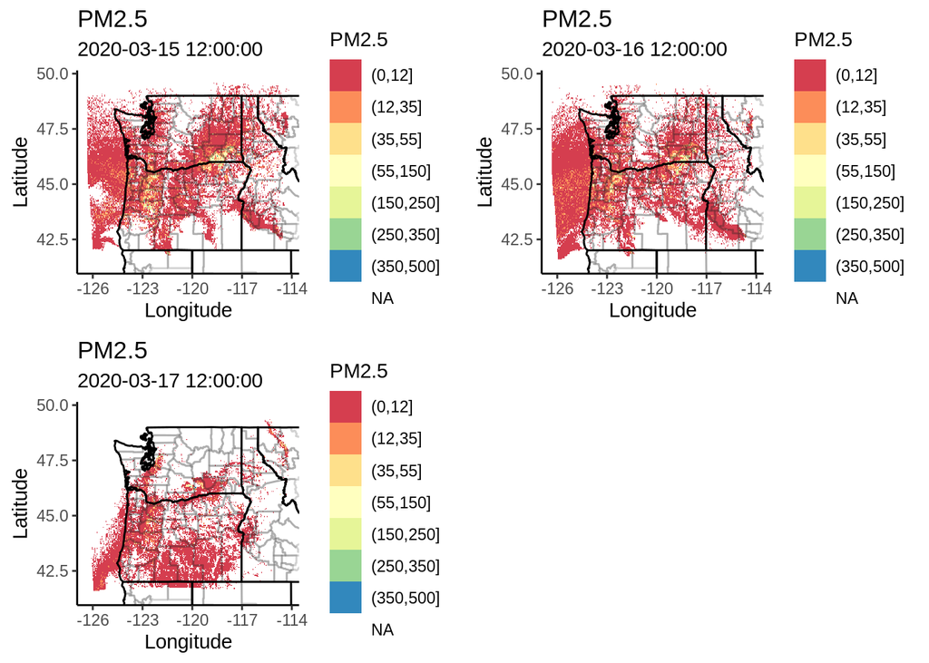

```r
maps_at_noon <- raster_map(pnw_1.33km, index = 12, palette = 'Spectral')
print(maps_at_noon)
```

Similarly, we can batch convert the models to monitors at a location, and combine them into a valid `ws_monitor` object.

```r
pnw_4km_monitor <- raster_toMonitor(pnw_4km, longitude = -120, latitude = 45)
```

As such we can do proceed as we normally would using any function that accepts a `ws_monitor` object.

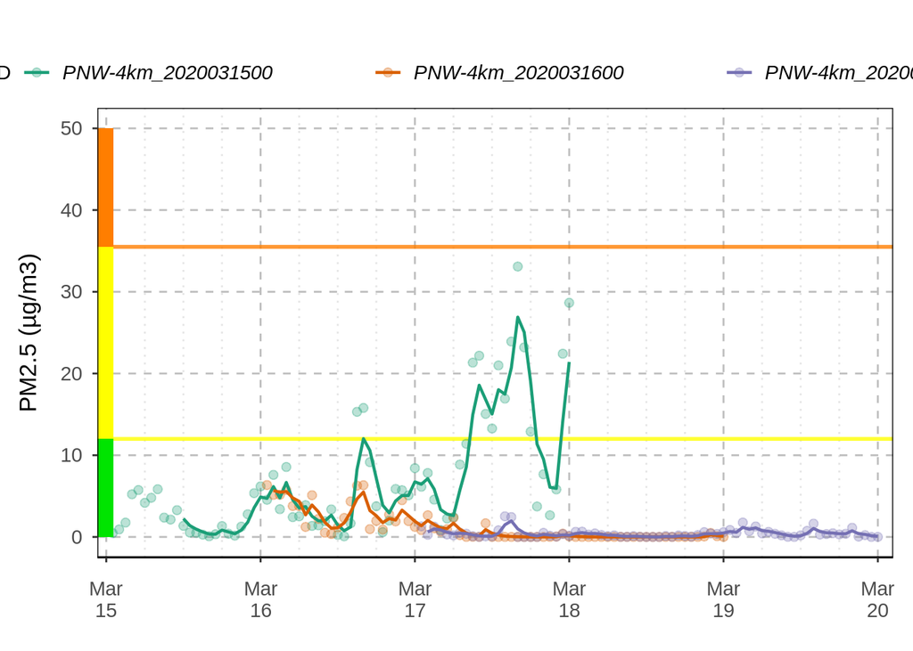

```r
pnw_4km_monitor %>%
  AirMonitorPlots::monitor_ggTimeseries()
```

Furthermore, we can plot coordinate traces of a location to compare with a regulatory monitor using batch mode.

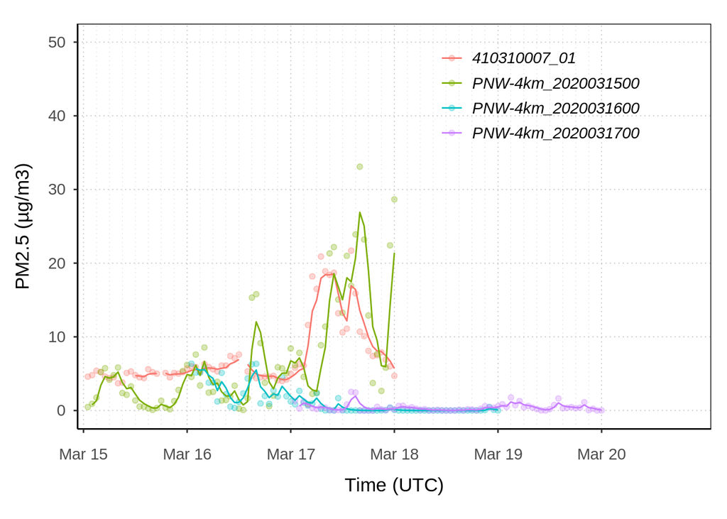

```r
traces <- raster_coordinateTrace(pnw_4km, longitude = -120, latitude = 45)
print(traces)
```

There are many other functions that can be extended to include batch mode. Below are a couple of more examples.

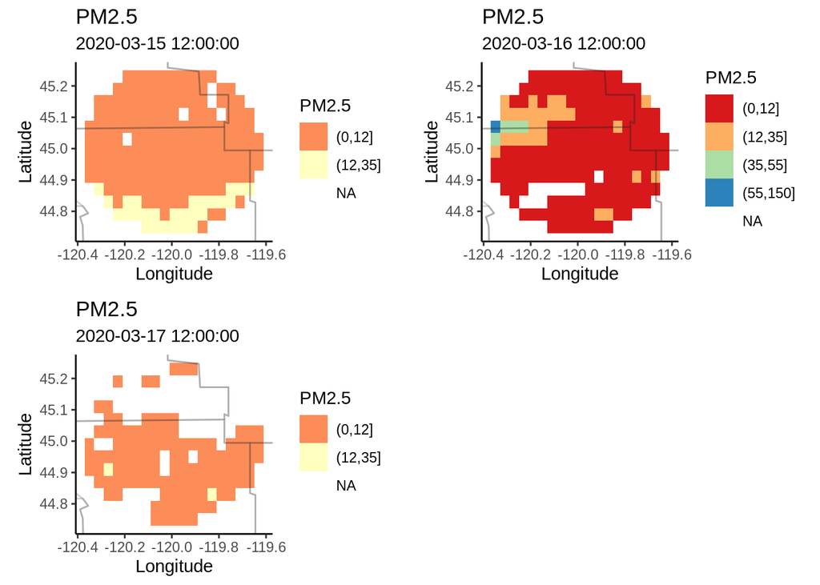

```r
pnw_4km_subbed <- raster_subset(pnw_4km, n = 200, longitude = -120, latitude = 45)
subbed_map <- raster_map(pnw_4km_subbed, index = 12, palette = 'Spectral')
print(subbed_map)
```

```r
calculated <- raster_calculate(pnw_4km, FUN = function(x) { x * 10 })
```